# Evaluating dynamic Gröbner Basis algorithms

Gabriel Mattos Langeloh

18/11/2019

# Introduction

The goal of this document is to do some exploratory analysis on dynamic Gröbner Basis algorithms. *Gröbner bases* (GB) are a fundamental tool in computer algebra to solve multivariate polynomial (non-linear) systems, among other applications. Traditional *static* Gröbner Basis algorithms receive an ordering (a vector) as part of the input. The performance of the algorithm, as well as the size of the output itself strongly depends on this input ordering. *Dynamic* Gröbner Basis algorithms were proposed to avoid having to choose an ordering a priori, computing one during the execution of the algorithm itself, hoping that this would lead to at least some of the following:

- shorter computation times
- fewer polynomials in the output
- sparser polynomials in the output
- polynomials of lower degree in the output

These are the main values that are computed in the experiments that follow. Six algorithms were used:

- the static algorithm (with a fixed input ordering, commonly used in the literature)
- the Gritzmann-Sturmfels algorithm (proposed in (Gritzmann and Sturmfels 1993), essentially a brute force search)
- the caboara-perry algorithm (proposed in (Caboara and Perry 2014), uses linear programming)
- the perturbation algorithm (new, looks for better orderings by applying perturbations to the current one)
- the random algorithm (new, does a random walk in the space of orderings)
- the local search algorithm (new, does a local search over the search space)

Due to particular traits of these algorithms, the perturbation and random algorithms only look for new orderings every 10 iterations of the Gröbner basis computation. It would also be interesting to find a better period more rigorously, but we do not do that here.

# Experimental setup and environment

All algorithms were implemented in the Sage computer algebra system (version 8.8, Python version 3.7.3) and share all basic functionality from the underlying algorithm used to compute Gröbner Bases. Our implementation is based on that of (Caboara and Perry 2014). Experiments were run on an AMD FX(tm)-8150 Eight-Core Processor @ 3.60GHz machine with 32GB of RAM.

All 30 instances were extracted from [Christian Eder’s benchmark library](https://github.com/ederc/singular-benchmarks) for Gröbner Bases. Each algorithm was run on every instance 30 times, the presented results corresponding to the mean of these runs. We used time limits of 60 minutes, and NA results correspond to timeouts.

Average results between groups of instances use the geometric mean, as some instances are much larger than others.

# Partial results from some previous works

The following table shows the results reported in (Caboara and Perry 2014), compared to our reproduction. Timings are not reported in the paper. We cannot reproduce these results, even using the code supplied in the original paper.

Attempt to reproduce results from Caboara and Perry (2014)

| instance | Original polynomials | Original monomials | Our polynomials | Our monomials |
| --- | --- | --- | --- | --- |
| cyclicn5 | 11 | 68 | 10 | 89 |
| cyclicn6 | 20 | 129 | 19 | 360 |
| cyclicn7 | 63 | 1049 | 59 | 6496 |
| cyclicnh5 | 11 | 98 | 21 | 296 |
| cyclicnh6 | 33 | 476 | 48 | 2580 |
| cyclicnh7 | 222 | 5181 | 113 | 29371 |
| katsuran6 | 22 | 54 | 23 | 593 |
| katsuran7 | 49 | 104 | 43 | 2156 |
| katsuranh6 | 23 | 164 | 24 | 634 |
| katsuranh7 | 46 | 352 | 52 | 2600 |

There are multiple possibilities for why we could not reproduce the results of the original paper. One is that their code may have changed between the publication of the paper and our access. As they did not provide the instances, only their names (they are all classical benchmarks in the literature) there may be slight differences in the instances themselves. Each instance is a list of polynomials - they may have been provided in a different order, leading to different results. Also, one of the properties of the instances (their characteristic) was not reported in the paper, so we had to choose an arbitrary value common in the literature.

For completeness, we also show the results from (Perry 2017), that uses a slightly modified version of the caboara-perry algorithm and a simple implementation in C++.

Comparison with the results of Perry (2017)

| instance | Their polynomials | Their monomials | Their time | Our polynomials | Our monomials | Our time |
| --- | --- | --- | --- | --- | --- | --- |
| cyclicn4 | 7 | 29 | 0.008 | 5 | 21 | 0.1133333 |
| cyclicnh4 | 4 | 15 | 0.014 | 5 | 21 | 0.1711538 |
| cyclicn5 | 13 | 165 | 0.059 | 10 | 89 | 0.8042308 |
| cyclicnh5 | 11 | 148 | 0.025 | 21 | 296 | 0.5724000 |
| cyclicn6 | 21 | 482 | 1.450 | 19 | 360 | 11.8400000 |
| cyclicnh6 | 38 | 1340 | 0.386 | 48 | 2580 | 2.9153846 |
| cyclicn7 | 54 | 9156 | 243.000 | 59 | 6496 | 1634.3835714 |
| cyclicnh7 | 107 | 27645 | 31.400 | 113 | 29371 | 68.9342308 |

Our implementation is much slower, but that is expected, as the implementation from (Perry 2017) is in C++ and ours is in Sage / Python. It is interesting to note, however, that for most instances their implementation is faster by almost a factor of 10. This is not the case of cyclicnh7, where it is only about 2 times faster. This points to an algorithmic advantage of the caboara-perry algorithm in this case.

# Exploratory analysis

## Classical reduction vs F4

Two reducers (a component of the general Gröbner Basis algorithm) were implemented: classical (based on polynomial arithmetic) and F4 (introduced in (Faugère 1999), uses matrix row reduction). F4 is usually considered to be faster in the context of traditional static Gröbner Basis algorithms. We observe this as well in our implementation, as shown by the table below.

Geometric means of the Static algorithm over all instances, by reducer.

| reducer | time |
| --- | --- |
| classical | 0.4084137 |
| F4 | 0.2463518 |

Is the speedup of using the F4 reducer kept for dynamic algorithms? In average, yes. The geometric mean of the running time, over all algorithms using the classical reducer is 1.4659164 while when we use the F4 reducer, we get 0.8378402.

The speedup of the F4 reducer is kept for most, but not all, pairs of instances and algorithms. The following graphs show results instance by instance, for three algorithms (Caboara-Perry, Static, Perturbation).

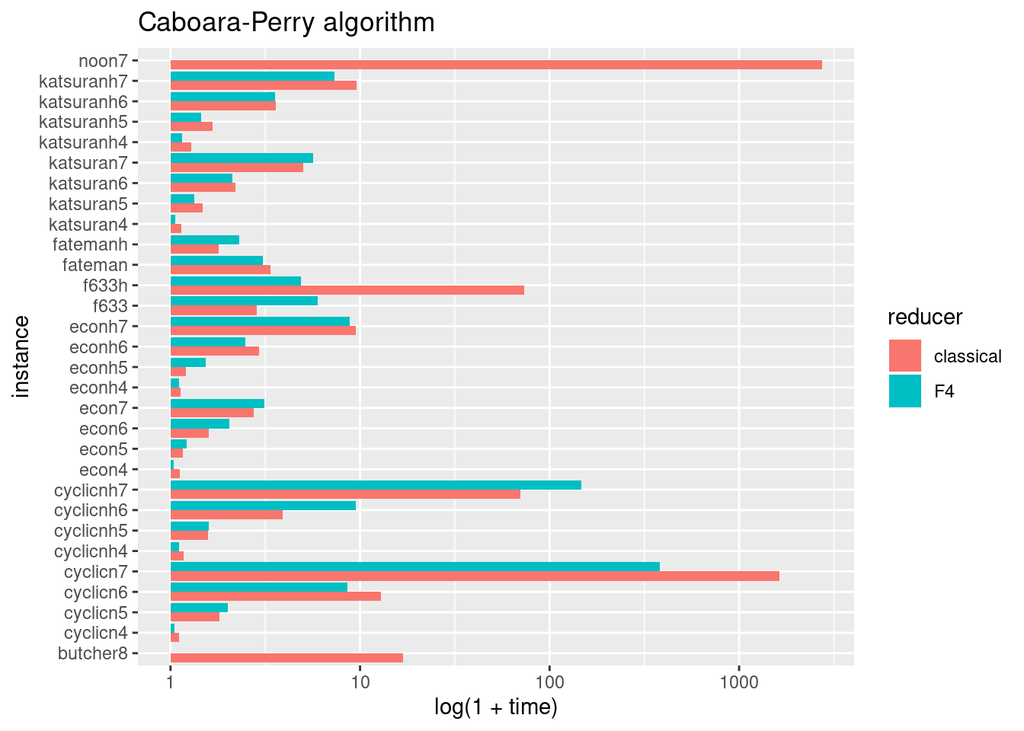

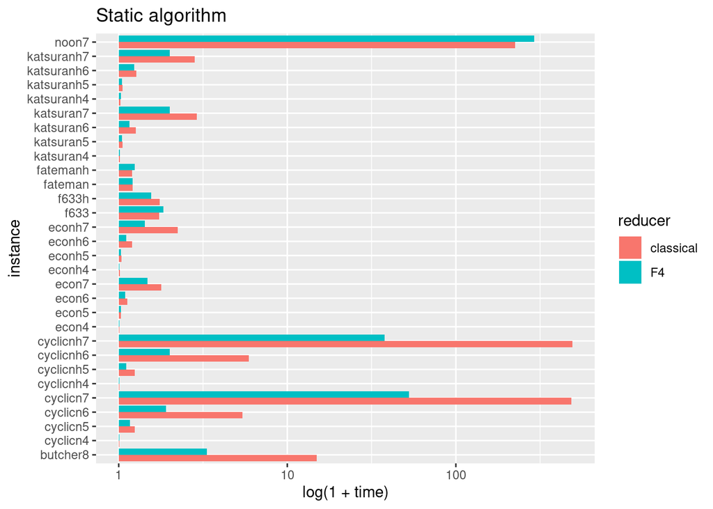

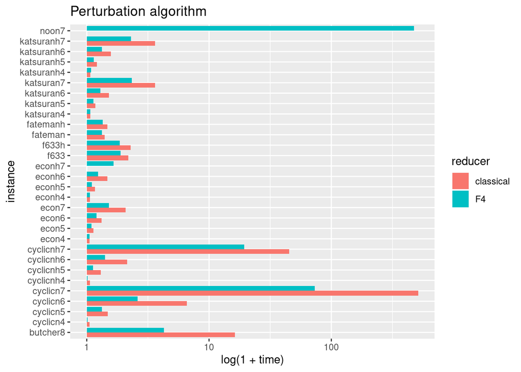

Note, further, that some running times do not appear in these graphs. In these cases, timeouts occurred. In a few cases, using the F4 reducer led to a timeout when the classical reducer did not.

## Comparing the dynamic Gröbner Basis algorithms

At first we focus on the five more viable algorithms (all but algorithm GS of Gritzmann and Sturmfels, as it is too slow to terminate in the time limit for most instances). To summarize the results, we compute the geometric mean of running time, the overhead of the dynamic components (time spent in the functions related to dynamic algorithms), number of polynomials and monomials of the output, and maximum degree of a polynomial in the output. The column S-reductions roughly corresponds to the number of iterations in the main loop of the algorithm.

Geometric means of each algorithm and reducer over all instances over which they did not timeout.

| algorithm | reducer | time | overhead | polynomials | monomials | degree | sreductions | timeout |
| --- | --- | --- | --- | --- | --- | --- | --- | --- |
| caboara-perry | classical | 2.0963985 | 1.0017316 | 21.01504 | 480.6154 | 8.884277 | 78.09137 | 0 |
| caboara-perry | F4 | 1.2768477 | 0.8772121 | 21.60659 | 400.6721 | 8.735790 | 507.12602 | 2 |
| perturbation | classical | 0.6165909 | 0.2517921 | 21.85991 | 383.7634 | 6.092866 | 70.21817 | 2 |
| perturbation | F4 | 0.4305515 | 0.1164181 | 25.11923 | 478.7229 | 6.339323 | 499.46348 | 0 |
| static | classical | 0.4084137 | 0.0000000 | 28.24804 | 528.8137 | 6.698443 | 94.37480 | 0 |
| static | F4 | 0.2463518 | 0.0000000 | 28.24804 | 528.8137 | 6.698443 | 461.86599 | 0 |
| random | classical | 1.7321794 | 0.3245233 | 23.26765 | 418.2865 | 6.555981 | 104.09040 | 2 |
| random | F4 | 0.4827347 | 0.0801335 | 27.80213 | 528.7928 | 6.891070 | 647.49335 | 0 |
| localsearch | classical | 9.6771200 | 9.1623217 | 15.75357 | 299.2875 | 8.424098 | 53.60944 | 5 |
| localsearch | F4 | 8.9003902 | 8.2688520 | 18.64869 | 281.9524 | 7.780246 | 1085.91830 | 4 |

Proportion of instances where each algorithm found the basis with fewest polynomials, classical reducer.

| algorithm | % fewest polynomials |
| --- | --- |
| caboara-perry | 0.5333333 |
| perturbation | 0.3000000 |
| static | 0.2666667 |
| random | 0.2333333 |
| localsearch | 0.4000000 |

Proportion of instances where each algorithm found the basis with lowest degree, classical reducer.

| algorithm | %lowest degree |
| --- | --- |
| caboara-perry | 0.4333333 |
| perturbation | 0.7000000 |
| static | 0.6666667 |
| random | 0.5000000 |
| localsearch | 0.2666667 |

Proportion of instances where each algorithm terminated more quickly, classical reducer.

| algorithm | % fastest |
| --- | --- |
| perturbation | 0.0666667 |
| static | 0.9333333 |

Proportion of instances where each algorithm found the basis with fewest polynomials, F4 reducer.

| algorithm | % fewest polynomials |
| --- | --- |
| caboara-perry | 0.3333333 |
| perturbation | 0.4333333 |
| static | 0.3000000 |
| random | 0.3333333 |
| localsearch | 0.4333333 |

Proportion of instances where each algorithm found the basis with lowest degree, F4 reducer.

| algorithm | % lowest degree |
| --- | --- |
| caboara-perry | 0.3666667 |
| perturbation | 0.8666667 |
| static | 0.7666667 |
| random | 0.6000000 |
| localsearch | 0.2333333 |

Proportion of instances where each algorithm terminated more quickly, F4 reducer.

| algorithm | % fastest |
| --- | --- |
| perturbation | 0.0666667 |
| static | 0.9000000 |
| random | 0.0333333 |

It is somewhat remarkable that the Random algorithm is able to find bases almost as small as Caboara-Perry and Perturbation, given that it simply visits random solutions. Even so, it seems to have no advantages when compared to Perturbation, as it is slower, and Perturbation is also very simple.

The Perturbation algorithm is faster than Caboara-Perry on most instances, due to its lower overhead, and it also leads to bases of lower degree. This is important - it is known that, asymptotically, large degrees lead to much worse running times, which gives evidence to the claim that Perturbation scales better than Caboara-Perry even though it returns slightly more polynomials.

The traditional Static algorithm still outperforms dynamic ones in terms of running time, unfortunately. Due to the overhead of the dynamic algorithms, this is always the case except when the dynamic algorithms manage to terminate in much fewer iterations. One such case is the homogeneous Cyclic family of instances. This is shown in the next table.

Behavior of the algorithms on a few larger instances.

| instance | algorithm | reducer | time | dynamic | polynomials | monomials | degree | sreductions |
| --- | --- | --- | --- | --- | --- | --- | --- | --- |
| cyclicnh6 | caboara-perry | classical | 2.915385e+00 | 1.436538e+00 | 48 | 2580 | 14 | 153 |
| cyclicnh6 | caboara-perry | F4 | 8.473333e+00 | 7.491250e+00 | 43 | 2112 | 12 | 899 |
| cyclicnh6 | perturbation | classical | 1.143448e+00 | 5.086207e-01 | 34 | 1540 | 9 | 102 |
| cyclicnh6 | perturbation | F4 | 4.107407e-01 | 8.222220e-02 | 34 | 1540 | 9 | 515 |
| cyclicnh6 | static | classical | 4.909231e+00 | 0.000000e+00 | 99 | 3502 | 15 | 389 |
| cyclicnh6 | static | F4 | 1.006800e+00 | 0.000000e+00 | 99 | 3502 | 15 | 1344 |
| cyclicnh7 | caboara-perry | classical | 6.893423e+01 | 2.847500e+01 | 113 | 29371 | 13 | 429 |
| cyclicnh7 | caboara-perry | F4 | 1.463012e+02 | 1.115885e+02 | 160 | 38330 | 15 | 5999 |
| cyclicnh7 | perturbation | classical | 4.430630e+01 | 4.167407e+00 | 121 | 28595 | 12 | 467 |
| cyclicnh7 | perturbation | F4 | 1.835364e+01 | 5.295455e-01 | 121 | 28595 | 12 | 3705 |
| cyclicnh7 | static | classical | 4.887015e+02 | 0.000000e+00 | 443 | 79897 | 19 | 2199 |
| cyclicnh7 | static | F4 | 3.674125e+01 | 0.000000e+00 | 443 | 79897 | 19 | 8752 |
| cyclicnh8 | static | F4 | 1.950100e+03 | 0.000000e+00 | 1182 | 676462 | 29 | 72296 |
| cyclicnh8 | perturbation | classical | 1.777190e+03 | 6.864000e+01 | 455 | 415782 | 17 | 2220 |
| cyclicnh8 | perturbation | F4 | 1.820610e+03 | 2.510000e+00 | 455 | 415782 | 17 | 50872 |
| cyclicnh8 | static | classical | 1.111402e+04 | 0.000000e+00 | 1182 | 676462 | 29 | 7026 |
| cyclicnh8 | caboara-perry | classical | 1.673038e+04 | 1.411822e+04 | 538 | 486535 | 20 | 2710 |

This is additional evidence that Perturbation may scale better out of the implemented algorithms. It is not possible to test this further, with the current implementation, because even larger instances take days to run. For this reason, a more efficient implementation of the dynamic algorithms, based on state-of-the-art Gröbner bases open source implementations is needed.

## Relationships between variables

Now we want to investigate the relationship between variables, such as running time and number of polynomials in the output. To do this, we first scatterplot a few of these pairs of variables.

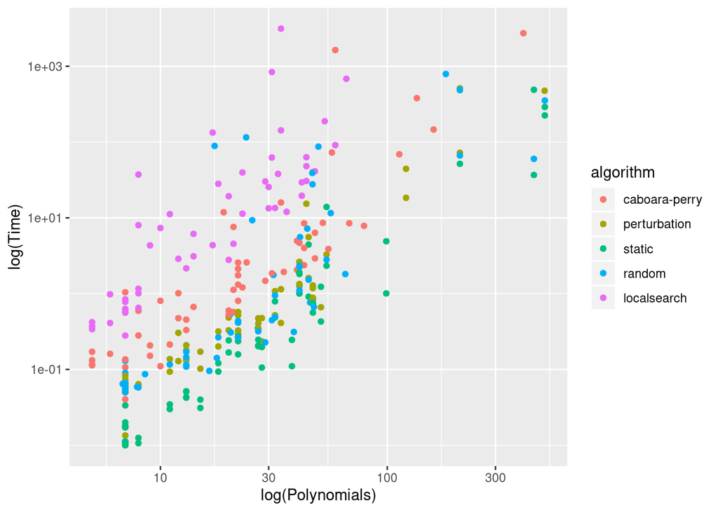

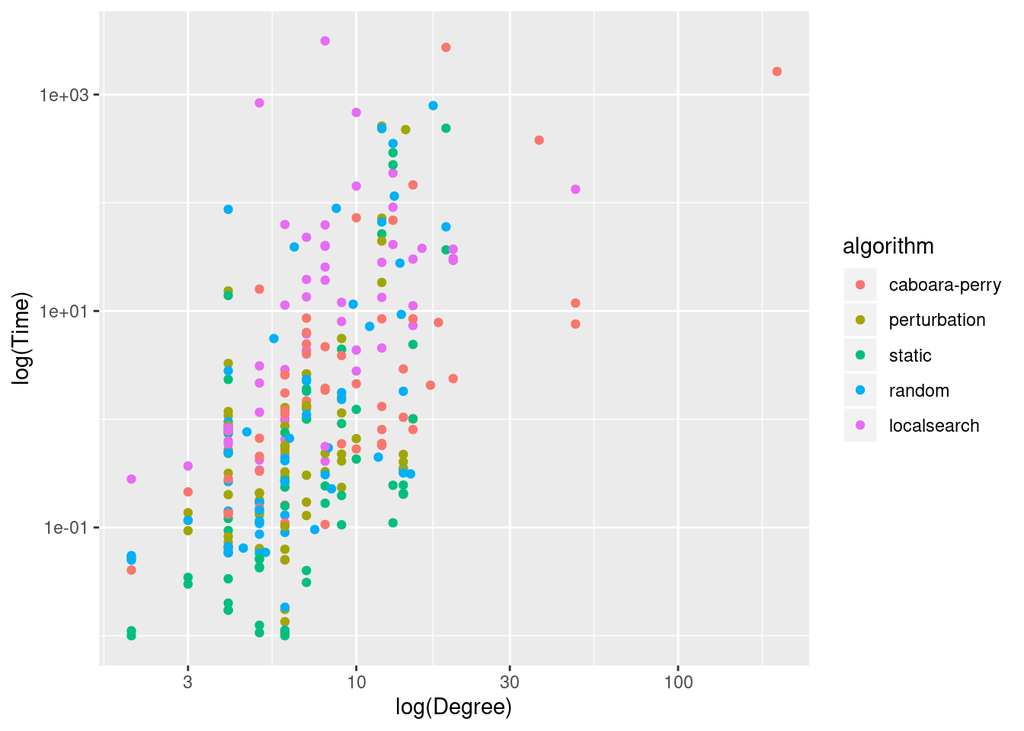

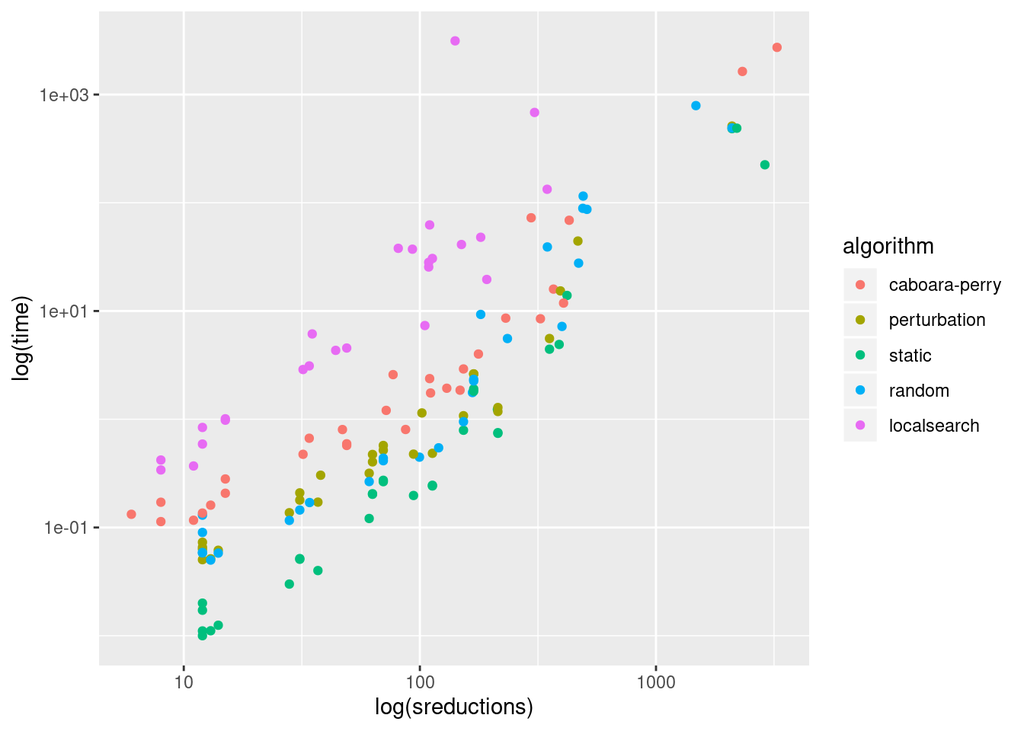

All three pairs seem (graphically) to be positively correlated. We compute their correlation for each algorithm and reducer separately:

Correlation between some variables and running time for each algorithm and reducer.

| algorithm | reducer | cor(polys, time) | cor(degree, time) | cor(sred, time) |
| --- | --- | --- | --- | --- |
| caboara-perry | classical | 0.8522316 | 0.5197642 | 0.9841311 |
| caboara-perry | F4 | 0.7687126 | 0.5252819 | 0.9566946 |
| perturbation | classical | 0.8714275 | 0.3499244 | 0.9692469 |
| perturbation | F4 | 0.9518927 | 0.4469483 | 0.9990046 |
| static | classical | 0.8134504 | 0.5604763 | 0.8798517 |
| static | F4 | 0.8064609 | 0.3305707 | 0.9981300 |
| random | classical | 0.9043825 | 0.5962662 | 0.8838139 |
| random | F4 | 0.8339828 | 0.3546356 | 0.9951154 |
| localsearch | classical | 0.2814003 | -0.0187399 | 0.2495890 |
| localsearch | F4 | 0.2842411 | -0.0809359 | 0.5741941 |

We observe that the correlation between sreductions and time is very high for most algorithms. This is not surprising, the number of iterations of the algorithm evidently predicts its running time. Most algorithms also have $> 0.8$ correlation between number of polynomials and running time. This is likely due to, in general, easier instances admitting smaller outputs. The degree, however, has a much lower correlation with the running time. This is contrary to the intuition from the literature, where asymptotic running times are often proven by bounds on the degree.

Interestingly, the results of the localsearch algorithm don’t follow the pattern of the remaining ones. This probably happens because the running time in this case is completely dominated by the dynamic overhead, which is mostly independent from the remaining parameters.

## Exploring the search space and the GS algorithm

The Gritzmann-Sturmfels algorithm (GS for short) is essentially a brute force on the search space, as it visits every available solution. It was proposed mostly as a theoretical tool with some interesting properties, and was not previously implemented. We implemented it, however, to check how close it is to optimality in the instances where it does not time out, as in these cases it is possible to compute the entire search space.

GS algorithm results whenever it did not time out, compared to optimal outputs. The columns minG and mindeg correspond to the minimal possible number of polynomials and degree, respectively. These may not be attainable at the same time.

| instance | time | dynamic | polynomials | monomials | degree | sreductions | minG | mindeg |
| --- | --- | --- | --- | --- | --- | --- | --- | --- |
| econ5 | 115.21 | 114.90 | 10 | 70 | 3 | 33 | 5 | 3 |
| econh4 | 461.15 | 459.52 | 10 | 51 | 6 | 158 | 4 | 3 |
| katsuranh4 | 5.67 | 5.60 | 7 | 49 | 4 | 30 | 7 | 4 |
| katsuran4 | 0.85 | 0.74 | 7 | 52 | 4 | 11 | 4 | 4 |
| cyclicn4 | 0.90 | 0.87 | 5 | 21 | 5 | 11 | 5 | 5 |
| cyclicnh4 | 1.88 | 1.85 | 4 | 17 | 4 | 10 | 4 | 4 |
| econ4 | 1.10 | 1.05 | 4 | 18 | 2 | 12 | 4 | 2 |

Below, we plot the search space of multiple small instances completely, along with the results of the algorithms whenever they are available. This is not the case for r4 and r4h, because they are random instances and not traditional literature benchmarks.

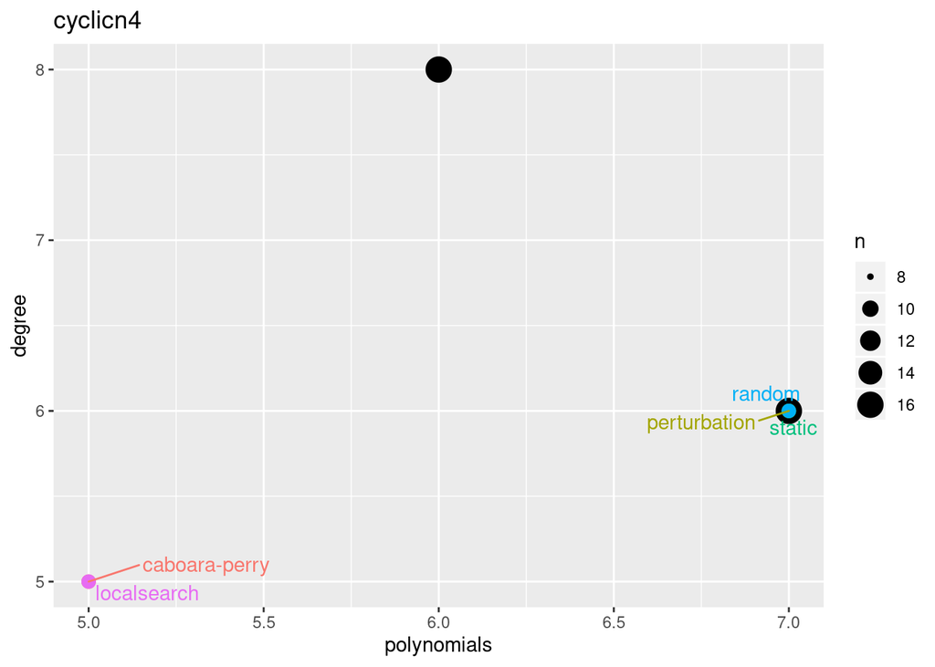

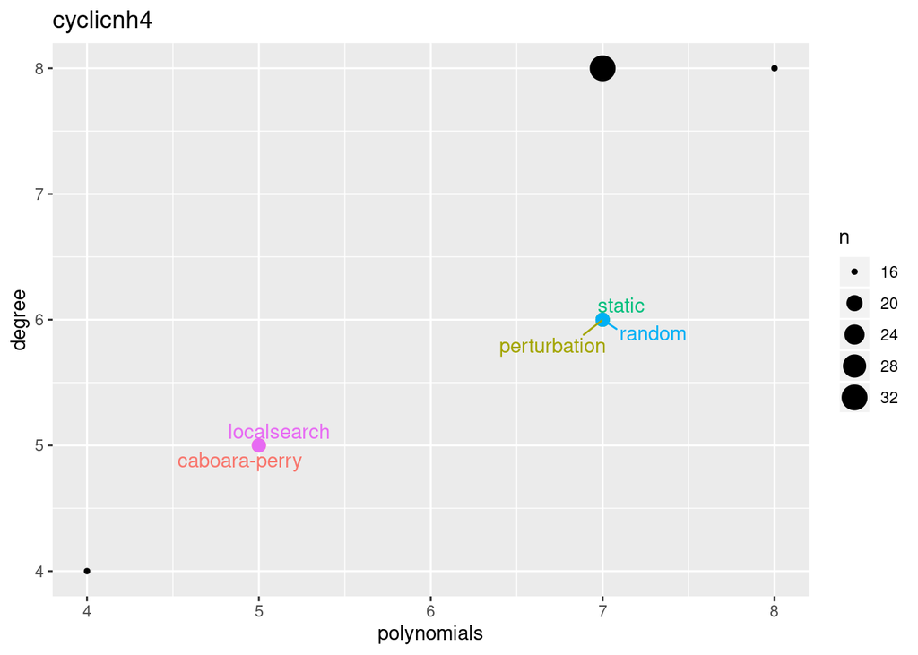

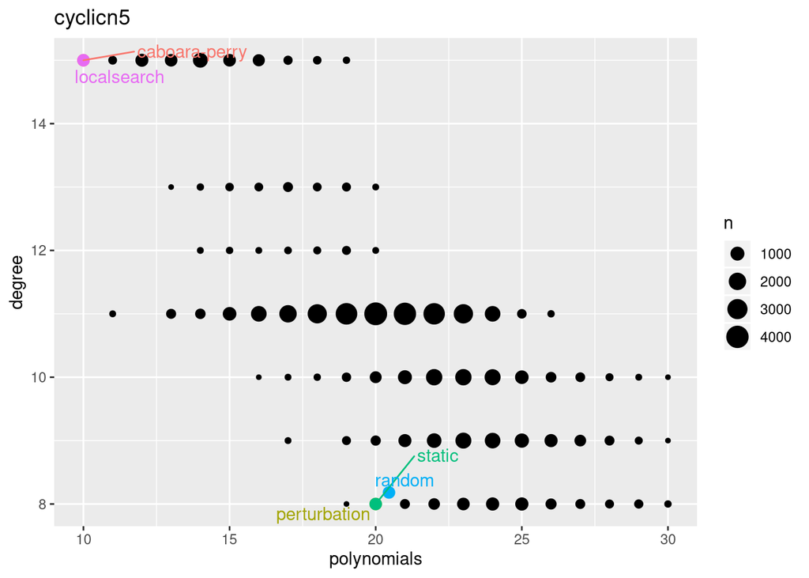

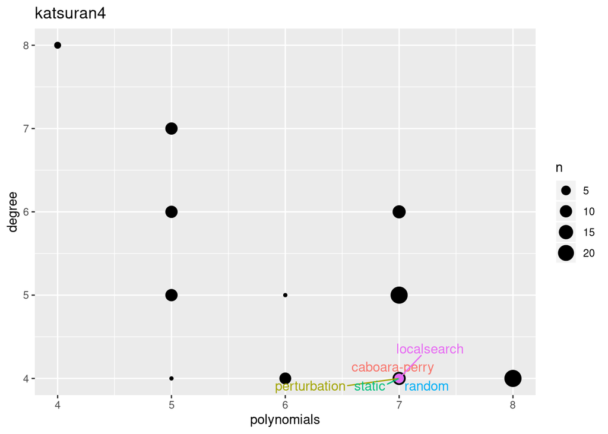

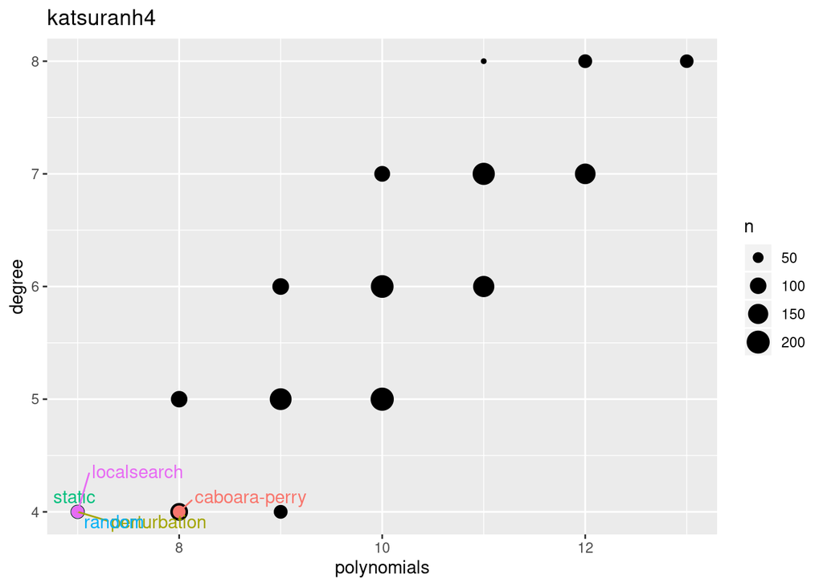

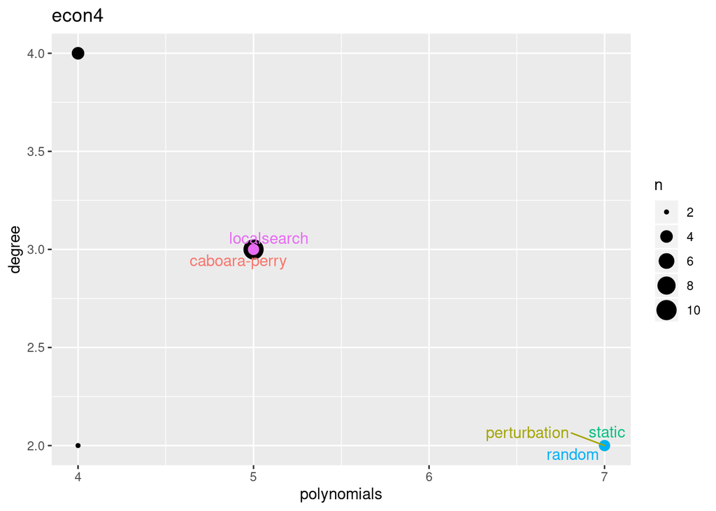

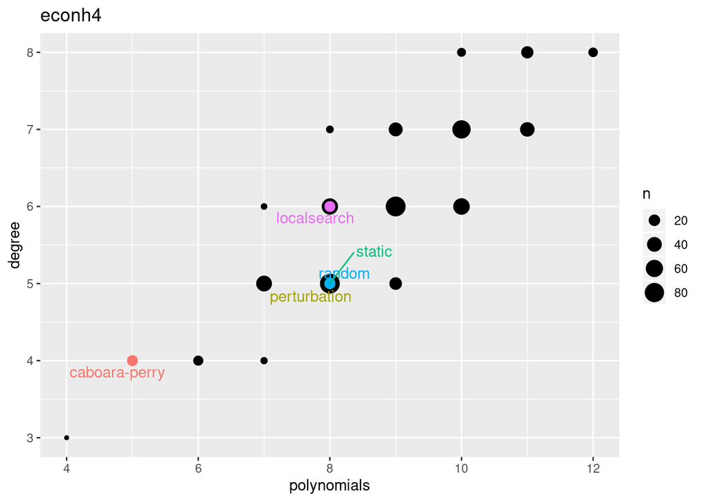

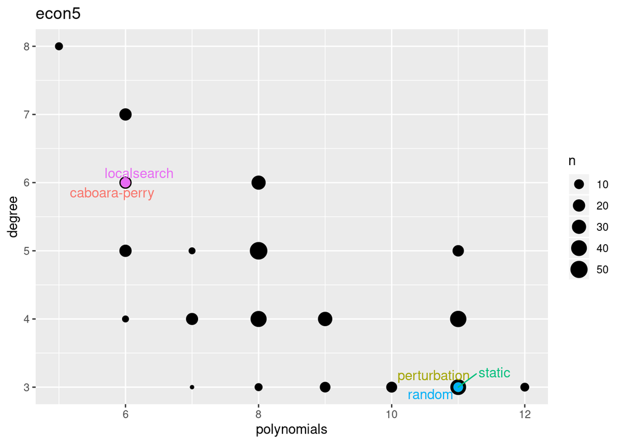

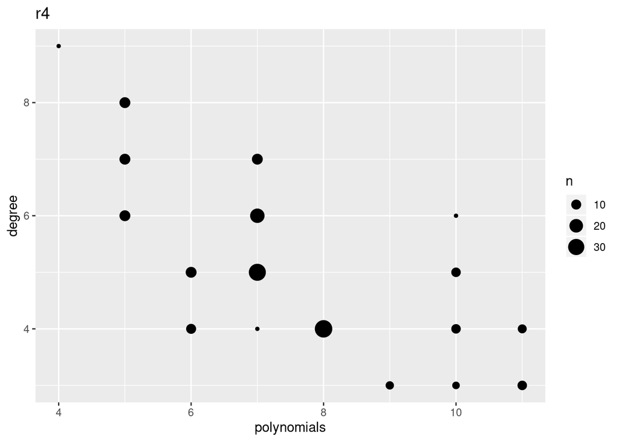

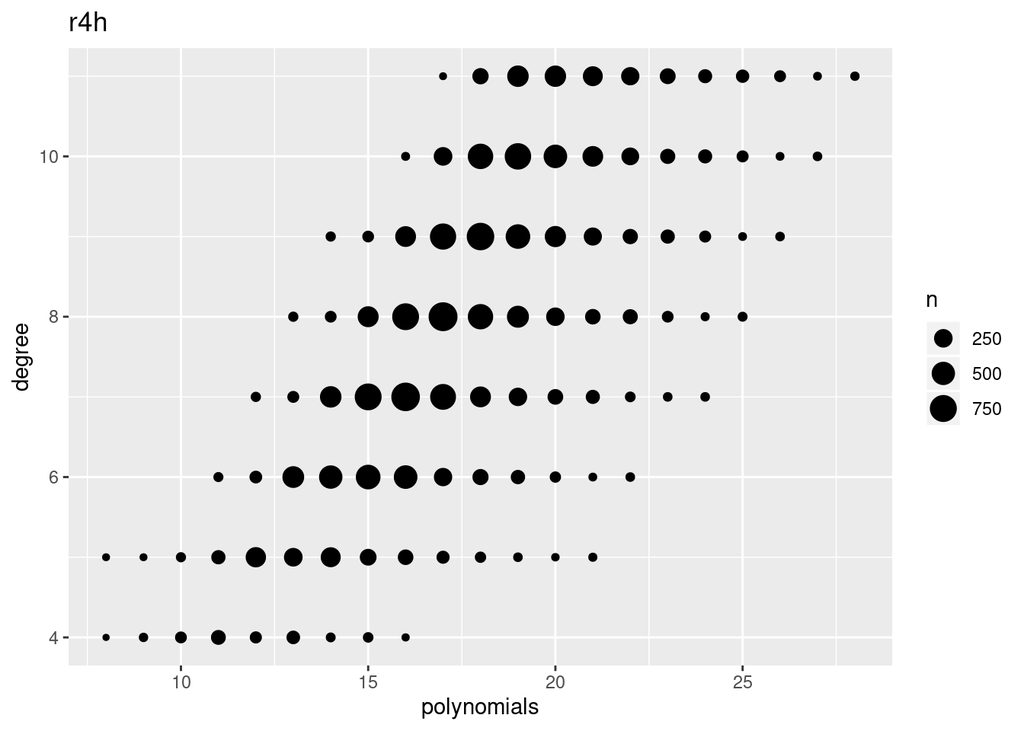

A simple interpretation of the quality of the output of the algorithms in these instances is that solutions closer to the bottom left are preferable. It is easy to observe that in many cases there is no solution minimizing both the degree and the number of polynomials at the same time. This means the problem of finding the “optimal” Gröbner Basis for an input is essentially a multi-objective optimization problem. At the time, it is not clear how to design algorithms that prioritize one over the other.

Regardless of the multi-objective characteristics of the problem, we can see that there is margin for improvement in many of these instances, even though they are small. Indeed, in many of them, there is an optimal solution and it is not found by any of the algorithms, or the solutions found are not in the Pareto curve of the instance (the Pareto curve of a multi-objective problem is the set of non-dominated solutions - a solution is dominated when some other solution is better than it with respect to every variable).

This multi-objective aspect was not previously observed in the literature - in fact, no previous work measures the degree of the output of the dynamic algorithms.

# Conclusions

- Currently, dynamic algorithms are not able to compete with traditional static ones except for larger instances.
- The new Perturbation algorithm is competitive with the previous best dynamic algorithm, the Caboara-Perry algorithm, and seems to scale better than it. A more efficient implementation is necessary to test this hypothesis more rigorously.
- There is a high correlation between time and sreductions and between time and polynomials in the output. The correlation between time and degree is not nearly as high, and that is somewhat surprising, when taking the theory of Gröbner Bases into account.
- There is a multi-objective aspect to dynamic Gröbner Basis algorithms, as one wants both outputs with low degree and small bases. We showed that often it is not possible to minimize both at the same time, and the current algorithms are not able to control what exactly they are minimizing.

# Bibliography

Caboara, Massimo, and John Perry. 2014. “Reducing the size and number of linear programs in a dynamic Gröbner basis algorithm.” *Applicable Algebra in Engineering, Communications and Computing* 25 (1-2): 99–117. https://doi.org/10.1007/s00200-014-0216-5.

Faugère, Jean-Charles. 1999. “A new efficient algorithm for computing Gröbner bases (F4).” *Journal of Pure and Applied Algebra* 139 (1). Elsevier: 61–88.

Gritzmann, Peter, and Bernd Sturmfels. 1993. “Minkowski Addition of Polytopes: Computational Complexity and Application to Gröbner Bases.” *SIAM J. Disc. Math.* 6 (2): 246–69.

Perry, John. 2017. “Exploring the Dynamic Buchberger Algorithm.” In *Proceedings of the 2017 International Symposium on Symbolic and Algebraic Computation*, 365–72.